# Survivial Analysis of Lung Cancer

Yifan Yang

This project is a comprehensive survival analysis utilizing Kaplan-Meier Model, Parametric Model (Exponential), Cox’s Proportional Hazards Model and Aalen’s Additive Hazards Model. The choice of model was tailored to the data’s characteristics and the specific objectives of the analysis.

|  | Kaplan-Meier Model | Exponential Model | Cox’s Proportional Hazards Model |
| --- | --- | --- | --- |
| PRO | 1. simple to interpret 2. can estimate survival rate | 1. can estimate survival function 2. can estimate hazard ratio | 1. hazard can fluctuate 2. can estimate hazard ratio |
| CON | 1. without survival function 2. can NOT estimate hazard ratio 3. can only include a few categorical factors | 1. not always realistic (assuming a constant hazard) | 1. can NOT estimate survival rate Can be improved by time-dependent coefficient model (*Aalen’s additive hazards model*) |

```r
library(survival)
library(survminer)
library(ranger)
library(ggplot2)
library(dplyr)
library(ggfortify)
```

## Aim

This research aims to elucidate the concept of survival analysis, highlighting the differences in methodologies and test statistics employed in the examination of survival data.

## datasets

This study will be using the Veterans’ Administrative Lung Cancer dataset(R Dataset) of 137 patients having advanced inoperable Lung cancer, carried out by the US Veterans Administration.

The factors included in the dataset are:

- trt: 1=standard 2=test
- celltype: 1=squamous, 2=smallcell, 3=adeno, 4=large
- time: survival time
- status: censoring status
- karno: Karnofsky performance score (100=good)
- diagtime: months from diagnosis to randomisation
- age: in years
- prior: prior therapy 0=no, 10=yes

```r
data(veteran)
head(veteran)
```

```
##   trt celltype time status karno diagtime age prior
## 1   1 squamous   72      1    60        7  69     0
## 2   1 squamous  411      1    70        5  64    10
## 3   1 squamous  228      1    60        3  38     0
## 4   1 squamous  126      1    60        9  63    10
## 5   1 squamous  118      1    70       11  65    10
## 6   1 squamous   10      1    20        5  49     0
```

## Kaplan-Meier Curve

```r
# Kaplan Meier Survival Curve
km <- with(veteran, Surv(time, status))

km.model <- survfit(Surv(time, status)~1, data = veteran,
                    type="kaplan-meier")

# summary of part of data
summary(km.model, time=seq(1, 900, by = 50))
```

```
## Call: survfit(formula = Surv(time, status) ~ 1, data = veteran, type = "kaplan-meier")
##
##  time n.risk n.event survival std.err lower 95% CI upper 95% CI
##     1    137       2    0.985  0.0102      0.96552       1.0000
##    51     84      53    0.597  0.0420      0.52032       0.6855
##   101     53      24    0.418  0.0425      0.34251       0.5101
##   151     34      18    0.272  0.0392      0.20490       0.3606
##   201     24       9    0.197  0.0355      0.13814       0.2802
##   251     17       5    0.153  0.0326      0.10088       0.2323
##   301     13       4    0.117  0.0295      0.07147       0.1917
##   351     11       2    0.099  0.0275      0.05743       0.1708
##   401      6       5    0.054  0.0211      0.02509       0.1163
##   451      5       1    0.045  0.0194      0.01931       0.1049
##   501      4       1    0.036  0.0175      0.01389       0.0934
##   551      4       0    0.036  0.0175      0.01389       0.0934
##   601      2       2    0.018  0.0126      0.00459       0.0707
##   651      2       0    0.018  0.0126      0.00459       0.0707
##   701      2       0    0.018  0.0126      0.00459       0.0707
##   751      2       0    0.018  0.0126      0.00459       0.0707
##   801      2       0    0.018  0.0126      0.00459       0.0707
##   851      2       0    0.018  0.0126      0.00459       0.0707
```

plot the KM model

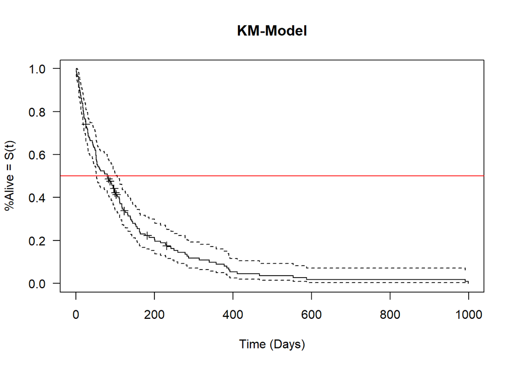

```r
plot(km.model, conf.int = T, xlab = "Time (Days)", ylab="%Alive = S(t)",
     main="KM-Model", las=1, mark.time = TRUE)

abline(h=0.5, col="red")
```

This ticks is the censor position. The red line represents the half survival rate. For more details, we examine the treatment which might influence the death rate.

```r
km.model2 <- survfit(Surv(time, status) ~ trt, data=veteran,
                    type="kaplan-meier")

# summary of part of data
summary(km.model2, time=seq(1, 900, by = 50))
```

```
## Call: survfit(formula = Surv(time, status) ~ trt, data = veteran, type = "kaplan-meier")
##
##                 trt=1
##  time n.risk n.event survival std.err lower 95% CI upper 95% CI
##     1     69       0   1.0000  0.0000      1.00000        1.000
##    51     46      23   0.6650  0.0570      0.56209        0.787
##   101     32      11   0.5020  0.0606      0.39615        0.636
##   151     19      13   0.2941  0.0568      0.20151        0.429
##   201     11       6   0.1947  0.0501      0.11761        0.322
##   251      8       3   0.1416  0.0448      0.07614        0.263
##   301      5       3   0.0885  0.0371      0.03896        0.201
##   351      4       1   0.0708  0.0336      0.02793        0.180
##   401      2       2   0.0354  0.0244      0.00917        0.137
##   451      1       1   0.0177  0.0175      0.00256        0.123
##   501      1       0   0.0177  0.0175      0.00256        0.123
```

[output cut: 22 more lines]

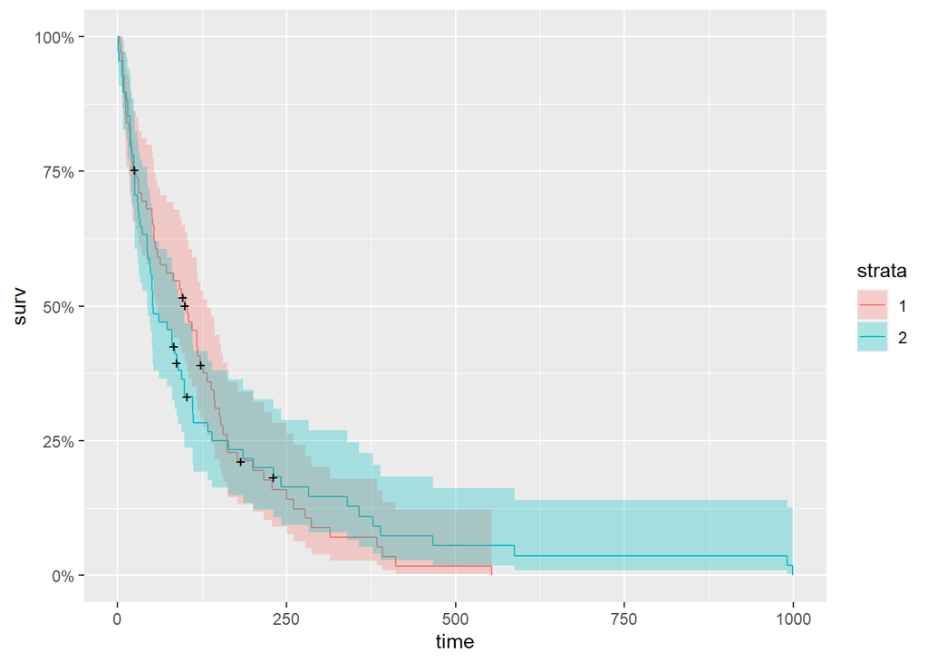

```r
autoplot(km.model2)
```

### log Rank test

The Log Rank test stands as one of the most widely adopted methods in survival analysis. It evaluates both the observed and expected number of events (failures) and establishes a chi-square statistic to test the null hypothesis. This test is applicable when the hazard rates between two groups run parallel.

```r
survdiff(Surv(time, status)~trt, data=veteran)
```

```
## Call:
## survdiff(formula = Surv(time, status) ~ trt, data = veteran)
##
##        N Observed Expected (O-E)^2/E (O-E)^2/V
## trt=1 69       64     64.5   0.00388   0.00823
## trt=2 68       64     63.5   0.00394   0.00823
##
##  Chisq= 0  on 1 degrees of freedom, p= 0.9
```

More beatiful and easy graph can be made using `survminer`

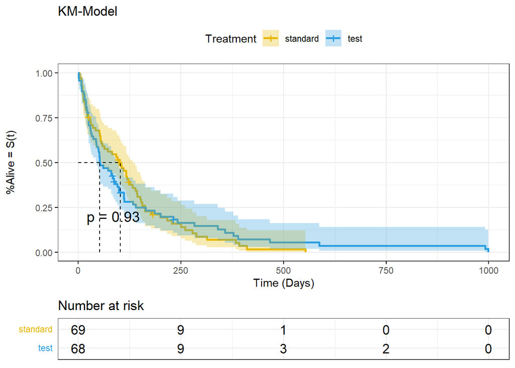

```r
ggsurvplot(
  km.model2,
  legend.labs = c("standard", "test"),
  legend.title = "Treatment",
  title = "KM-Model",

  xlab = "Time (Days)",
  ylab = "%Alive = S(t)",
  # Add p-value and tervals
  pval = TRUE,
  log.rank.weights = "1",# weights=1 corresponding to log-rank test

  conf.int = TRUE,
  # Add risk table
  risk.table = TRUE,
  tables.height = 0.2,
  tables.theme = theme_cleantable(),
  surv.median.line = "hv",  # add the median survival pointer.


  palette = c("#E7B800", "#2E9FDF"),
  ggtheme = theme_bw() # Change ggplot2 theme)
)
```

Kaplan Meier survival curves were constructed for both treatment showed almost identical survival pattern and has p-value much larger than 0.05, indicating there is no significant effects.

### Wilcoxon test

Unlike the Log Rank test, Wilcoxon test method operates on the principle that the exponentiated coefficient [Exp(B)] for the two groups need not remain constant, thus particularly well-suited for analyzing early failures in survival data.

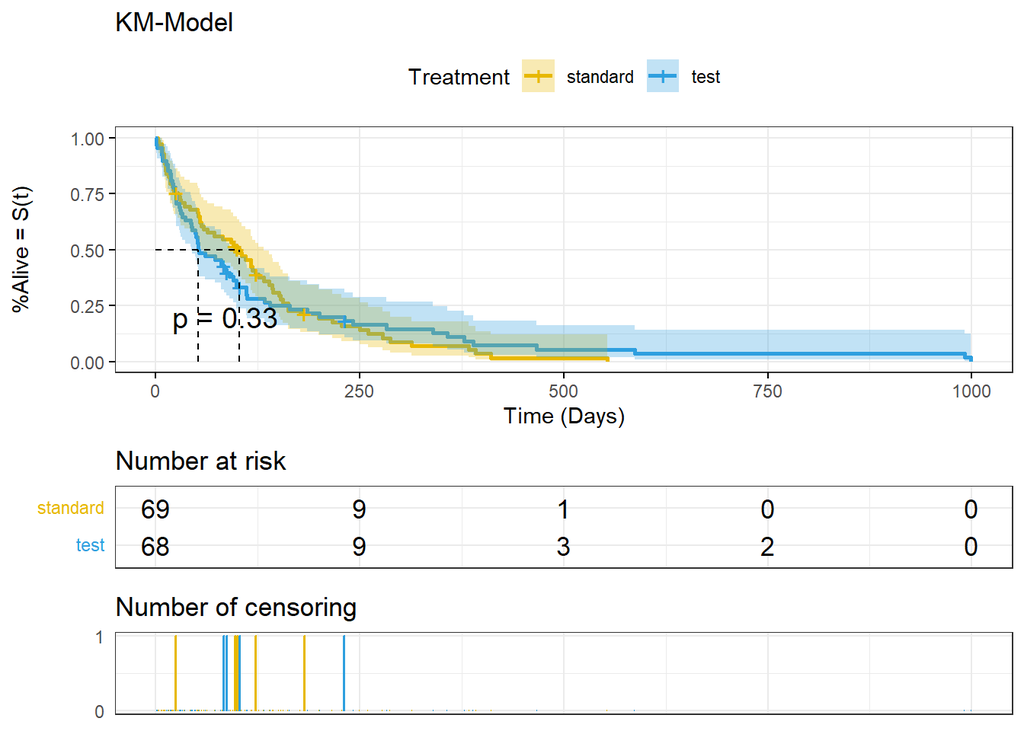

```r
ggsurvplot(
  km.model2,
  legend.labs = c("standard", "test"),
  legend.title = "Treatment",
  title = "KM-Model",

  xlab = "Time (Days)",
  ylab = "%Alive = S(t)",
  # Add p-value and tervals
  pval = TRUE,
  log.rank.weights = "n",# weights=n corresponding to generalized Wilcoxon test

  conf.int = TRUE,
  # Add risk table
  risk.table = TRUE,
  tables.height = 0.2,
  tables.theme = theme_cleantable(),

  ncensor.plot = TRUE,      # plot the number of censored subjects at time t
  surv.median.line = "hv",  # add the median survival pointer.

  palette = c("#E7B800", "#2E9FDF"),
  ggtheme = theme_bw() # Change ggplot2 theme)
)
```

## regression model

Kaplan-Meier model is a non-parametric method. Here we test the results on a parametric model.

### exponential model

Using the Concept of exponential distribution, where
$$s(t) = P(T > t) = 1 - F(t) = e^{-\lambda t}$$

The hazard rate, represented by $\lambda$, is calculated using the formula:

$$\lambda = e^{(b_0 + b_1 X_1 + b_2 X_2 +
\ldots + b_k X_k)}$$

Exponential model fit with all covariates

```r
em <- survreg(Surv(time, status) ~ trt + celltype + karno + diagtime + age + prior ,
              data = veteran, dist = "exp")

summary(em)
```

```
##
## Call:
## survreg(formula = Surv(time, status) ~ trt + celltype + karno +
##     diagtime + age + prior, data = veteran, dist = "exp")
##                       Value Std. Error     z       p
## (Intercept)        3.408176   0.734373  4.64 3.5e-06
## trt               -0.219565   0.198634 -1.11  0.2690
## celltypesmallcell -0.820245   0.262111 -3.13  0.0018
## celltypeadeno     -1.113121   0.275825 -4.04 5.4e-05
## celltypelarge     -0.377220   0.272626 -1.38  0.1665
## karno              0.030624   0.005108  6.00 2.0e-09
## diagtime          -0.000297   0.008970 -0.03  0.9736
## age                0.006108   0.009161  0.67  0.5049
## prior             -0.004948   0.022687 -0.22  0.8273
##
## Scale fixed at 1
##
## Exponential distribution
## Loglik(model)= -716.2   Loglik(intercept only)= -751.2
##  Chisq= 70.12 on 8 degrees of freedom, p= 4.6e-12
## Number of Newton-Raphson Iterations: 5
## n= 137
```

Plot regression model requires create dataframe

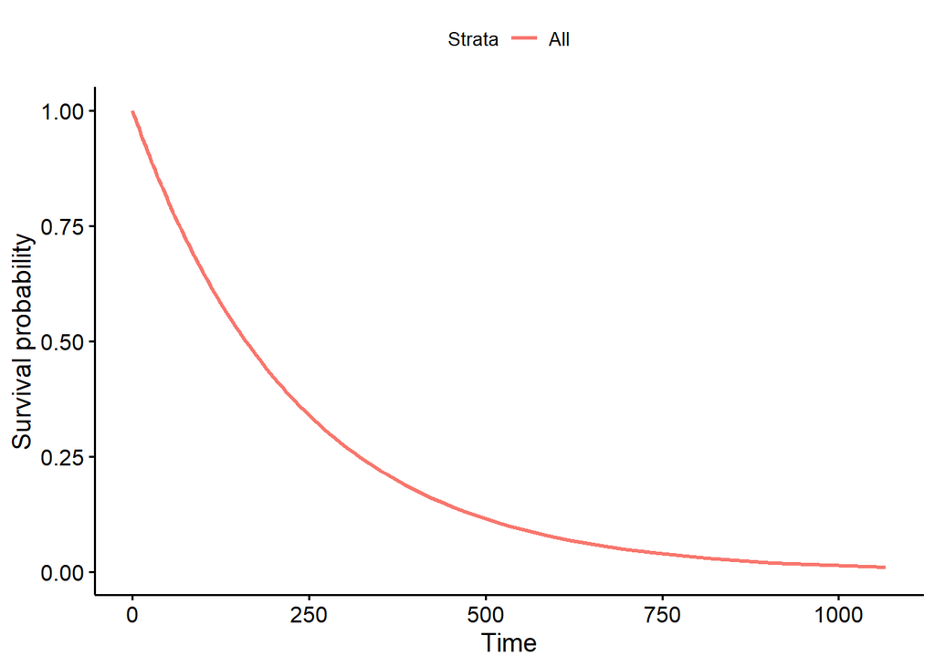

```r
s <- seq(.01, .99, by = .01)
t <- predict(em, type = "quantile", p = s, newdata = veteran[1, ])
out_em <- data.frame(time = t, surv = 1 - s, upper = NA, lower = NA, std.err = NA)

p_em <- ggsurvplot(out_em, conf.int = FALSE, surv.geom = geom_line)
p_em
```

```r
wb <- survreg(Surv(time, status) ~ trt + celltype + karno + diagtime + age + prior , data = veteran, dist = "exp")

summary(wb)
```

```
##
## Call:
## survreg(formula = Surv(time, status) ~ trt + celltype + karno +
##     diagtime + age + prior, data = veteran, dist = "exp")
##                       Value Std. Error     z       p
## (Intercept)        3.408176   0.734373  4.64 3.5e-06
## trt               -0.219565   0.198634 -1.11  0.2690
## celltypesmallcell -0.820245   0.262111 -3.13  0.0018
## celltypeadeno     -1.113121   0.275825 -4.04 5.4e-05
## celltypelarge     -0.377220   0.272626 -1.38  0.1665
## karno              0.030624   0.005108  6.00 2.0e-09
## diagtime          -0.000297   0.008970 -0.03  0.9736
## age                0.006108   0.009161  0.67  0.5049
## prior             -0.004948   0.022687 -0.22  0.8273
##
## Scale fixed at 1
##
## Exponential distribution
## Loglik(model)= -716.2   Loglik(intercept only)= -751.2
##  Chisq= 70.12 on 8 degrees of freedom, p= 4.6e-12
## Number of Newton-Raphson Iterations: 5
## n= 137
```

## Cox Proportional Hazards Model

This model benefits by allowing Harvard to change over time, but hazard ratio between different groups is constant.

If we fit Cox Proportional Hazards Model against treatment

```r
cox <- coxph(Surv(time, status) ~ trt, data = veteran)

summary(cox)
```

```
## Call:
## coxph(formula = Surv(time, status) ~ trt, data = veteran)
##
##   n= 137, number of events= 128
##
##        coef exp(coef) se(coef)     z Pr(>|z|)
## trt 0.01774   1.01790  0.18066 0.098    0.922
##
##     exp(coef) exp(-coef) lower .95 upper .95
## trt     1.018     0.9824    0.7144      1.45
##
## Concordance= 0.525  (se = 0.026 )
## Likelihood ratio test= 0.01  on 1 df,   p=0.9
## Wald test            = 0.01  on 1 df,   p=0.9
## Score (logrank) test = 0.01  on 1 df,   p=0.9
```

`exp(coef)` can be interpret as at a given instant in time, person who in this circumstance is `exp(coef)` likely to die with adjusting for other factors.

With `exp(coef)` close to 1 and p values much larger than 0.05, people with test treatment and people with standard treatment does not have significanly difference in survival rate. Agree with previous results.

If we fit Cox Proportional Hazards Model using all the factor in the dataset.

```r
cox2 <- coxph(Surv(time, status) ~ trt + celltype + karno + diagtime + age + prior , data = veteran)

summary(cox2)
```

```
## Call:
## coxph(formula = Surv(time, status) ~ trt + celltype + karno +
##     diagtime + age + prior, data = veteran)
##
##   n= 137, number of events= 128
##
##                         coef  exp(coef)   se(coef)      z Pr(>|z|)
## trt                2.946e-01  1.343e+00  2.075e-01  1.419  0.15577
## celltypesmallcell  8.616e-01  2.367e+00  2.753e-01  3.130  0.00175 **
## celltypeadeno      1.196e+00  3.307e+00  3.009e-01  3.975 7.05e-05 ***
## celltypelarge      4.013e-01  1.494e+00  2.827e-01  1.420  0.15574
## karno             -3.282e-02  9.677e-01  5.508e-03 -5.958 2.55e-09 ***
## diagtime           8.132e-05  1.000e+00  9.136e-03  0.009  0.99290
## age               -8.706e-03  9.913e-01  9.300e-03 -0.936  0.34920
## prior              7.159e-03  1.007e+00  2.323e-02  0.308  0.75794
## ---
## Signif. codes:  0 '***' 0.001 '**' 0.01 '*' 0.05 '.' 0.1 ' ' 1
##
##                   exp(coef) exp(-coef) lower .95 upper .95
## trt                  1.3426     0.7448    0.8939    2.0166
## celltypesmallcell    2.3669     0.4225    1.3799    4.0597
## celltypeadeno        3.3071     0.3024    1.8336    5.9647
## celltypelarge        1.4938     0.6695    0.8583    2.5996
## karno                0.9677     1.0334    0.9573    0.9782
## diagtime             1.0001     0.9999    0.9823    1.0182
## age                  0.9913     1.0087    0.9734    1.0096
## prior                1.0072     0.9929    0.9624    1.0541
##
## Concordance= 0.736  (se = 0.021 )
## Likelihood ratio test= 62.1  on 8 df,   p=2e-10
## Wald test            = 62.37  on 8 df,   p=2e-10
## Score (logrank) test = 66.74  on 8 df,   p=2e-11
```

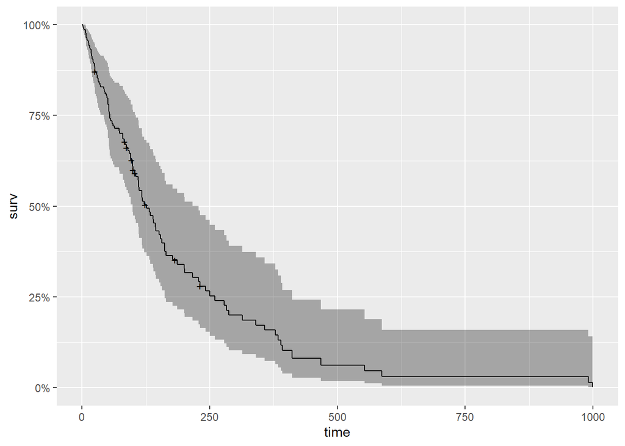

```r
cox_fit2 <- survfit(cox2)
autoplot(cox_fit2)
```

### likelihood ratio test (LRT)

It can be used to compare these two model

```r
anova(cox, cox2, test="LRT")
```

```
## Analysis of Deviance Table
##  Cox model: response is  Surv(time, status)
##  Model 1: ~ trt
##  Model 2: ~ trt + celltype + karno + diagtime + age + prior
##    loglik  Chisq Df Pr(>|Chi|)
## 1 -505.44
## 2 -474.40 62.094  7  5.756e-11 ***
## ---
## Signif. codes:  0 '***' 0.001 '**' 0.01 '*' 0.05 '.' 0.1 ' ' 1
```

p-value is significant small, thus the second model is better. The adding of other factors increase the prediction power.

From the second model, we found the factor celltypesmallcell, celltypeadeno and karno are with significant p-values, indicating that they are all statistically significant to the risk of death happening.

### Check the assumption of Cox Proportional Hazards Model

While the Cox Proportional Hazard’s model is thought to be “robust”, we need to check the underlying assumptions. The violation of assumptions indicate the inaccuray of model results.

1. check linearity

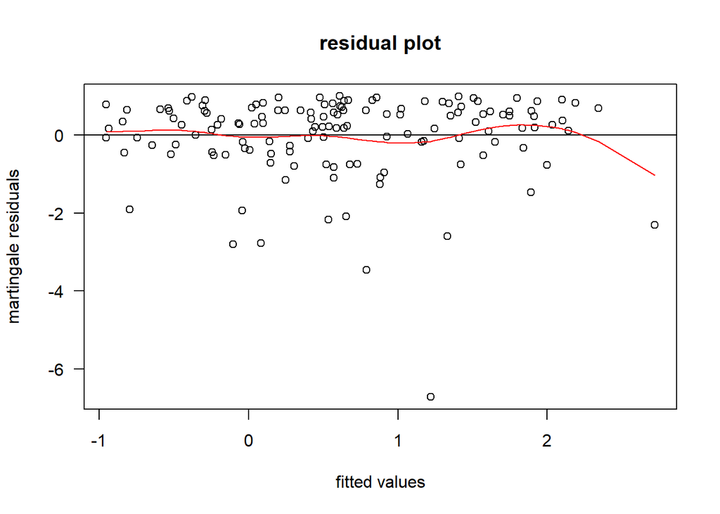

```r
plot(predict(cox2), residuals(cox2, type="martingale"),
     xlab="fitted values", ylab="martingale residuals",
     main="residual plot", las=1)

abline(h=0)

lines(smooth.spline(predict(cox2), residuals(cox2, type="martingale")),
                    col="red")
```

we can valid the linearity of the data.

2. check the proportional hazard’s assumptions (PH assumption)

Using Schoenfeld test. H_0: Hazards are proportional.

```r
cox.zph(cox2)
```

```
##            chisq df       p
## trt       0.2644  1 0.60712
## celltype 15.2274  3 0.00163
## karno    12.9352  1 0.00032
## diagtime  0.0129  1 0.90961
## age       1.8288  1 0.17627
## prior     2.1656  1 0.14113
## GLOBAL   34.5525  8 3.2e-05
```

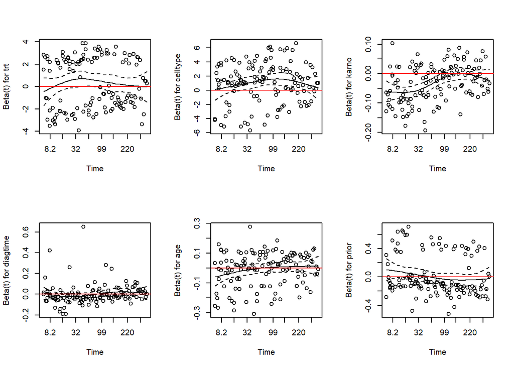

```r
par(mfrow=c(2,3))
# Loop through each plot
for(i in 1:6) {
  # Generate the plot using cox.zph()
  plot(cox.zph(cox2)[i])

  # Add a horizontal line at h=0 with red color
  abline(h=0, col="red")
}
```

The graph demonstrate if we allowed the hazard to change overtime.

The solid line represents if we allow change, how hazard will change.

The graph for the karno deviate from zero, may indicating the violation of PH assumption. We could stratified this parameter, or use time-depends coefficient model, allowing hazard change overtime.

## Aalen’s additive hazards model

Aalen’s additive hazards model is a method that can be used as an alternative to the Cox proportional hazards model when the proportional hazards (PH) assumption is violated. When the PH assumption is not met, the relationship between the predictor variables and the hazard rate may change over time, and this can lead to biased or misleading results if using the Cox model.

Aalen’s additive hazards model allows for the coefficients of the predictors to vary over time, thereby accommodating non-proportional hazards.

> “The Aalen model assumes that the cumulative hazard H(t) for a subject can be expressed as a(t) + X B(t), where a(t) is a time-dependent intercept term, X is the vector of covariates for the subject (possibly time-dependent), and B(t) is a time-dependent matrix of coefficients.”

```r
aa_model <-aareg(Surv(time, status) ~ trt + celltype + karno + diagtime + age + prior ,                  data = veteran)
aa_model
```

```
## Call:
## aareg(formula = Surv(time, status) ~ trt + celltype + karno +
##     diagtime + age + prior, data = veteran)
##
##   n= 137
##     75 out of 97 unique event times used
##
##                       slope      coef se(coef)      z        p
## Intercept          0.066400  3.45e-02 1.06e-02  3.250 1.14e-03
## trt                0.006730  2.49e-03 2.58e-03  0.967 3.34e-01
## celltypesmallcell  0.015000  7.30e-03 3.38e-03  2.160 3.09e-02
## celltypeadeno      0.018400  1.03e-02 4.20e-03  2.450 1.42e-02
## celltypelarge     -0.001090 -6.21e-04 2.71e-03 -0.229 8.19e-01
## karno             -0.001180 -4.37e-04 8.77e-05 -4.980 6.28e-07
## diagtime          -0.000243 -4.92e-05 1.64e-04 -0.300 7.65e-01
## age               -0.000246 -6.27e-05 1.28e-04 -0.491 6.23e-01
## prior              0.000330  1.54e-04 2.86e-04  0.539 5.90e-01
##
## Chisq=41.62 on 8 df, p=1.6e-06; test weights=aalen
```

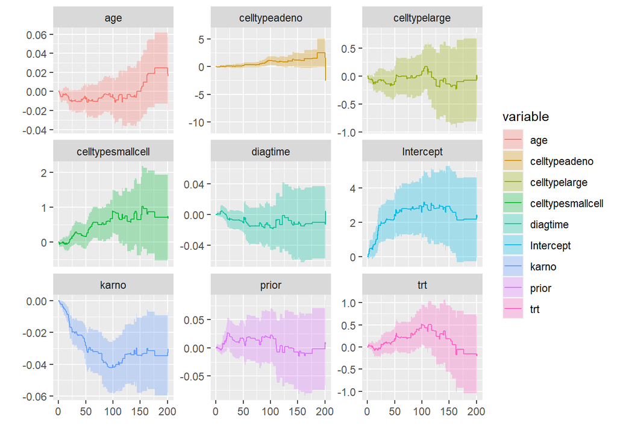

```r
autoplot(aa_model)
```

This graphs shows how the covariates influence hazards change over time